# Analyzing the Effect of Race on Maryland Traffic Stop Outcomes

# Introduction

A traffic stop is a temporary detention of a vehicle and driver by police to investigate a possible crime or minor violation of the law on the grounds of reasonable suspicion that a crime has occurred or is about to occur. This standard was set by the U.S. Supreme Court in 1968 by the landmark case Terry v. Ohio. Once a police officer executes a traffic stop based on reasonable suspicion, the primary purpose is usually to determine if there is probable cause for arrest. In example, a police officer may suspect that a driver is driving under the influence (DUI) based on observed behavior and perform a traffic stop. After this, a breathalyzer test would be sufficient evidence to secure a warrant for arrest.

The issue lies within the officer's preconceptions and personal judgement in establishing reasonable suspicion. Traffic stops disproportionally affect people of color who are more likely to get pulled over for trivial reasons. More recently there has been a push to reform traffic stops and ban low-level pretexts for stops such as: driving with a broke headlight or brake light, having a registration plate that not clearing displayed or fastened, driving without an inspection or emissions sticker, bumper issues, minor obstructions, etc.

In 2015, the Stanford Computational Journalism Lab and the Stanford Computation Policy Lab started the Open Policing Project which collects and analyzes traffic stop data from across the country (E. Pierson). The data varies greatly between the states in it's availability, variety, and coverage. One dataset that has been excluded from the Open Policing Project's analysis was the Maryland data which, among other factors, lacked locational data.

In this tutorial, my goal is to tidy the Maryland traffic stop dataset collected from both State Patrol and local jurisdictions - [available here](https://openpolicing.stanford.edu/data/) - and provide insights into the rate of traffic stops among different ethnic groups in different jurisdictions.

# Imports and Python Libraries

```python
# Libraries used in this tutorial
import pandas as pd
import numpy as np
import matplotlib.pyplot as plt
from sklearn import model_selection
from sklearn.linear_model import LinearRegression
import statsmodels.api as sm
import warnings
warnings.filterwarnings('ignore')
```

# Reading the data

After reading the csv we obtained from the Open Policing Project, we find that there are almost 3.7 million recorded stops with 28 columns.

```python
# This dataset is large, so reading it may take a minute
stops_raw = pd.read_csv('data/md_statewide_2020_04_01.csv')
stops_raw.head()
print(stops_raw.shape)
```

```
(3669665, 28)
```

## Pecularities of the Maryland Traffic Stops dataset

As mentioned previously, the Maryland dataset was more messy than the other state's data. It has some notable factors which limit the amount of useful data that can be used for any further analysis. Firstly, the data comes from three different time periods: 2007, 2009-2012, and 2013-2014. They all have different columns (which were combined together in the final csv) and slightly different conventions of how things are recorded. Before 2013, traffic stops were reported annually. Any stops from this period are only accurate to the year in which the stop was made. Month and day are filled with the values Jan 1. From 2013 onward, data is reported daily, allowing for better analysis.

Also, the Open Policing Project noted that prior to 2013 there are quite a few NAs for contraband which are not casted as false since this data is suspected to be missing. In effect, we cannot rely on the records before 2013 for analyzing the number of vehicle searches or contraband found.

Due to the reasons above, we will focus on rows that have a recorded date for the traffic stop and years 2013 and after. This includes records from 2013-2014. Ultimately, this reduces the rows from 3669665 to 842138.

```python
# Stops which do not have a date listed are dropped to allow for selecting of years 2013 and after
stops_raw = stops_raw[stops_raw['date'].notna()]
stops = stops_raw[stops_raw['date'].str.contains('2013|2014')]
stops.reset_index(drop = True, inplace = True)
```

```python
print(stops.shape)
```

```
(842138, 28)
```

# Tidying and Modifying the Data

## Removing unused columns

First we drop these columns: disposition, violation, reason_for_stop. The disposition and violation columns vary widely across police departments and are present in 1.9% and 0.1% of the rows respectively. We will drop these columns as they are not useful for our analysis and lack standardized information. The reason_for_stop column is reported as a freeform text field indicating the reason for stop where provided. While the coverage of this column is high at 99.2%, it contains police jargon which I can't decode. Therefore, we will drop this column as it also provides no useful information for our analysis. Next, we will drop the type column as all recorded stops in Maryland are vehicular. Finally, we will also drop the raw columns (raw_row_number, raw_Race, raw_Outcome, raw_Arrest_Made) as they contain redundant information already expounded upon in other columns.

```python
stops = stops.drop(['raw_row_number', 'type', 'disposition', 'violation', 'reason_for_stop', 'raw_Race', 'raw_Outcome', 'raw_Arrest_Made'], axis = 1)
print(stops.shape)
```

```
(842138, 20)
```

```python
stops.head()
```

|  | date | time | location | subject_age | subject_race | subject_sex | department_name | arrest_made | citation_issued | warning_issued | outcome | contraband_found | contraband_drugs | contraband_weapons | search_conducted | search_person | search_vehicle | search_basis | reason_for_arrest | reason_for_search |
| --- | --- | --- | --- | --- | --- | --- | --- | --- | --- | --- | --- | --- | --- | --- | --- | --- | --- | --- | --- | --- |
| 0 | 2013-01-01 | 18:16:00 | SRT22@PARADISE RD | 31.0 | hispanic | male | Aberdeen Police Department | False | False | False | NaN | NaN | NaN | NaN | False | False | False | NaN | NaN | NaN |
| 1 | 2013-01-01 | 14:37:00 | 879 BEARDSHILL RD | 32.0 | asian/pacific islander | female | Aberdeen Police Department | False | False | True | warning | NaN | NaN | NaN | False | False | False | NaN | NaN | NaN |
| 2 | 2013-01-01 | 22:00:00 | SRT22@BEARDSHILL RD | 31.0 | white | female | Aberdeen Police Department | False | False | True | warning | NaN | NaN | NaN | False | False | False | NaN | NaN | NaN |
| 3 | 2013-01-01 | 21:29:00 | SRT22@BEARDSHILL RD | 38.0 | hispanic | male | Aberdeen Police Department | False | False | True | warning | NaN | NaN | NaN | False | False | False | NaN | NaN | NaN |
| 4 | 2013-01-02 | 19:12:00 | SRT40@W BEL AIR AVE | 61.0 | white | male | Aberdeen Police Department | False | True | False | citation | NaN | NaN | NaN | False | False | False | NaN | NaN | NaN |

# Exploratory Data Analysis

For this section, we'll take a preliminary look into the data to see if there are any interesting aspects. Let's create a summary by department and track their total stops, arrests, citations, and warnings issued to see how the stops are distributed between the departments.

```python
# Lowercasing and removing leading and tailing spaces from the department_name column
stops.reset_index(inplace = True, drop = True)
stops['department_name'] = stops['department_name'].str.lower()
stops['department_name'] = stops['department_name'].str.strip()

# Grouping by department
by_department = stops.groupby(['department_name'], as_index=False).agg({'arrest_made': 'sum', 'citation_issued': 'sum', 'warning_issued': 'sum', 'outcome': 'count'})
```

```python
print(by_department.shape)
```

```
(209, 5)
```

After grouping the data by department, we see that there are 209 departments, give or take.

Let's pick the top 20 departments with the most stops to focus on. Since some of the department names have entries as acronyms and other's use the full name. For example, Prince Geroge's County Police Department is also represented by PGCOPD. I will manually combine these entries together

```python
by_department.sort_values(inplace = True, by = 'outcome', ascending=False, ignore_index = True)

equivalents = {'maryland state police': 'msp', 'baltimore county police department': None, 'montgomery county police department': 'montgomery',
               'maryland transportation authority police': 'mdta', 'anne arundel county police department': None, 'prince george\'s county police department': 'pgcopd',
               'howard county police department': 'hocpd', 'frederick police department': 'frederickpd', 'ocean city police department': 'oceancity',
               'charles county sheriff\'s office': 'charles', 'harford county sheriff\'s office': 'harford', 'university of maryland college park police': 'umcp',
              'greenbelt police department': 'greenbelt', 'calvert county sheriff\'s office': 'calvert', 'carroll county sheriff\'s office': 'carroll',
               'annapolis police department': None, 'washington county sheriff\'s office': 'washington', 'laurel police department': 'laurel',
               'gaithersburg police department': 'gaithersburg', 'rockville police department': 'rockville'}

top_20_department = pd.DataFrame()
for key in equivalents:
    eq = equivalents[key]
    if eq:
        x = by_department[by_department['department_name'] == key]
        y = by_department[by_department['department_name'] == eq]
        x['arrest_made'] = int(x['arrest_made']) + int(y['arrest_made'])
        x['citation_issued'] = int(x['citation_issued']) + int(y['citation_issued'])
        x['warning_issued'] = int(x['warning_issued']) + int(y['warning_issued'])
        x['outcome'] = int(x['outcome']) + int(y['outcome'])
        top_20_department = top_20_department.append(x, ignore_index = True)
    else:
        top_20_department = top_20_department.append(by_department[by_department['department_name'] == key], ignore_index = True)

print(top_20_department.to_string())
```

```
                               department_name arrest_made citation_issued warning_issued  outcome
0                        maryland state police        1667           93424         115355   210445
1           baltimore county police department        1455           22308          60416    84179
2          montgomery county police department        1969           30710          35216    67895
3     maryland transportation authority police         472           17414          39833    57719
4        anne arundel county police department         816           14315          32100    47231
5     prince george's county police department         544           24697          15383    40624
6              howard county police department        2004            9227          19960    31191
7                  frederick police department         868            5729          12814    19411
8                 ocean city police department         763            4056           9547    14366
9              charles county sheriff's office         394            4059           5973    10426
10             harford county sheriff's office         164            2236           7905    10305
11  university of maryland college park police         188            3230           5899     9317
12                 greenbelt police department         108            2376           5308     7792
13             calvert county sheriff's office         159            1580           4620     6359
14             carroll county sheriff's office          50            2360           4146     6556
15                 annapolis police department         353            2581           1828     4762
16          washington county sheriff's office          99            2185           3834     6118
17                    laurel police department         205            3166           2130     5501
18              gaithersburg police department          92            3194           2501     5787
19                 rockville police department          46            1788           3106     4940
```

Here are how the stops are distributed among the departments

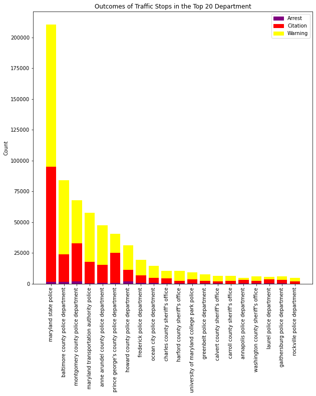

```python
plt.figure(figsize=(10, 10))
plt.bar(top_20_department.department_name, top_20_department.arrest_made, color='purple')
plt.bar(top_20_department.department_name, top_20_department.citation_issued, bottom=top_20_department.arrest_made, color='red')
plt.bar(top_20_department.department_name, top_20_department.warning_issued, bottom=top_20_department.arrest_made + top_20_department.citation_issued, color='yellow')
plt.xticks(rotation = 90)
colors = {'Arrest':'purple', 'Citation':'red', 'Warning': 'yellow'}
labels = list(colors.keys())
handles = [plt.Rectangle((0,0),1,1, color=colors[label]) for label in labels]
plt.legend(handles, labels)
plt.ylabel('Count')
plt.title('Outcomes of Traffic Stops in the Top 20 Department')

plt.show()
```

As we can expect, departments with a more populated jurisdiction will have more traffic stops. The number of stops seems to be logarithmically decreasing starting with the Maryland State Police which covers the entire state. In the future we will have to standardize for the total amount of stops made.

## Graphing race of arrest, citations, and warnings given by these departments and standardize by population distribution

Let's take a closer look at 4 out of these 20 departments. We'll look at Maryland State Police, Balitmore County PD, Montgomery County PD and Prince George's County PD. Of course, using the raw counts of arrests, citations, and warnings can be misleading as it does not account for the population of each department's jurisdiction, we must convert to account for the population distribution. To this end, I manually grabbed some data from the [US census](https://www.census.gov/quickfacts/fact/table/MD,princegeorgescountymaryland,montgomerycountymaryland,baltimorecountymaryland/POP010210) on the racial profile of each of the counties, and in the Maryland State Patrol's case, the racial profile of Maryland as a whole.

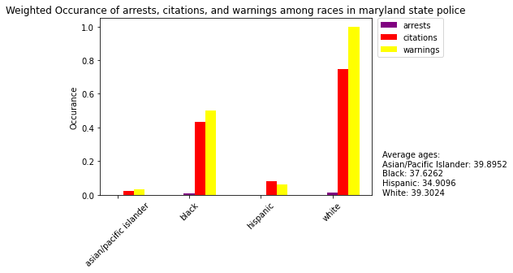

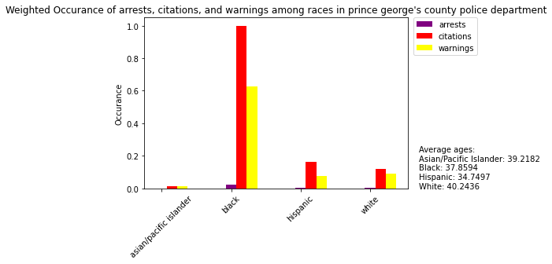

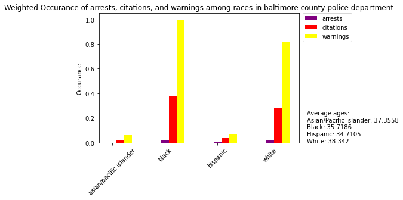

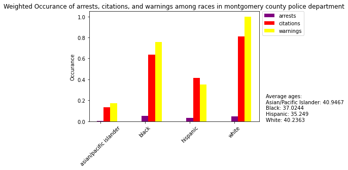

```python
# Changing sex data so that it is countable
stops['subject_sex'].replace('female', 0, inplace = True)
stops['subject_sex'].replace('male', 1, inplace = True)
stops['outcome'].replace(np.NaN, 'none', inplace = True)

# Grouping by department and race
by_department_race = stops.groupby(['department_name', 'subject_race'], as_index=False).agg({'arrest_made': 'sum', 'citation_issued': 'sum',
                                                                                             'warning_issued': 'sum', 'outcome': 'count',
                                                                                             'subject_age': 'mean', 'subject_sex': 'sum',
                                                                                             'search_conducted': 'sum', 'contraband_found': 'sum'})

wanted = {'maryland state police': 'msp', 'prince george\'s county police department': 'pgcopd', 'baltimore county police department': None,
          'montgomery county police department': 'montgomery'}
# Department: [asian/pacific islander pop %, black pop %, hispanic pop %, white pop %]
# https://www.census.gov/quickfacts/fact/table/MD,princegeorgescountymaryland,montgomerycountymaryland,baltimorecountymaryland/POP010210
pop_dis = {'maryland state police': [.067, .311, .106, .500],
          'prince george\'s county police department': [.044, .644, .195, .123],
          'baltimore county police department': [.063, .303, .058, .558],
          'montgomery county police department': [.156, .201, .201, .429]}

for department in wanted:
    current = by_department_race[by_department_race['department_name'] == department]

    # Combining acronyms and spelled out department names
    if wanted[department]:
        current = pd.concat([current,
                             by_department_race[by_department_race['department_name'] == equivalents[department]]], ignore_index = True)
    dups = current['department_name'].unique().size

    by_race = current.groupby(['subject_race'], as_index = False).agg({'arrest_made': 'sum', 'citation_issued': 'sum',
                                                            'warning_issued': 'sum', 'subject_age': 'sum', 'outcome': 'sum', 'subject_sex': 'sum'})

    # Averaging the ages
    by_race['subject_age'] = by_race['subject_age'] / dups

    # Drop the unknowns
    by_race = by_race[by_race['subject_race'].str.contains('unknown|other')==False]
    by_race.reset_index(drop = True, inplace = True)

    # Normalize by tallest bar
    max_bar = 0
    for index, race in by_race.iterrows():
        max_bar = max(max_bar, race['arrest_made'], race['warning_issued'], race['citation_issued'])

    # Applying weights to each race
    for index, race in by_race.iterrows():
        by_race.at[index, 'arrest_made'] = race['arrest_made']/pop_dis.get(department)[index]/(max_bar/pop_dis.get(department)[index])
        by_race.at[index, 'warning_issued'] = race['warning_issued']/pop_dis.get(department)[index]/(max_bar/pop_dis.get(department)[index])
        by_race.at[index, 'citation_issued'] = race['citation_issued']/pop_dis.get(department)[index]/(max_bar/pop_dis.get(department)[index])

    fig, ax = plt.subplots()
    X = np.arange(by_race['subject_race'].size)

    ax.bar(X, by_race.arrest_made,  width = 0.15, color = 'Purple')
    ax.bar(X + .15, by_race.citation_issued,  width = 0.15, color = 'Red')
    ax.bar(X + .3, by_race.warning_issued,  width = 0.15, color = 'Yellow')
    ax.set_xticks(X, by_race['subject_race'])
    plt.xticks(rotation = 45)
    ax.set_title('Weighted Occurance of arrests, citations, and warnings among races in ' + str(department))
    ax.legend(labels=['arrests','citations','warnings'], bbox_to_anchor=(1.02, 1), loc='upper left', borderaxespad=0)

    avg_age = by_race['subject_age']
    #for index, race in by_race.iterrows():

    textstr = "Average ages:\nAsian/Pacific Islander: " +  str(round(by_race['subject_age'][0],4)) + "\nBlack: " +  str(round(by_race['subject_age'][1],4))
    textstr = textstr  + "\nHispanic: " +  str(round(by_race['subject_age'][2],4)) + "\nWhite: " +  str(round(by_race['subject_age'][3],4))
    ax.text(3.7, 0, textstr)
    ax.set_ylabel('Occurance')

    plt.show()
```

Based on the above graphs, we can see that despite accounting for the distribution of different races among the populace of each county, some races are overrepresented in citations and warnings. For example, in Prince George's County Police Department and Baltimore County Police Department, police seem to stop African American drivers often than any other race. On the other hand, Maryland State Police and Montgomery Country Police Department stop Caucasians more often.

## How is the rate of searches different among minorities

To look for racial bias during traffic stops, we can look at the number of times police have searched a stopped vehicle of a minority as compared to a Caucasian. Below I plot the number of minority searches per 100 stops over the number of white searches per 100 stops. In a perfect world, i.e. if all other parameters were equal, the identity line (y=x) would represent equality between the races. We use the measure of searches per 100 stops to normalize over the difference in the number of stops of a given race, and set the x axis to be the white searches as this will be our comparative baseline. In jurisdictions with more white searches (and therefore more searches in general) we would expect more searches of all races. The graph below measures how these extra searches are distributed proportionally among the races.

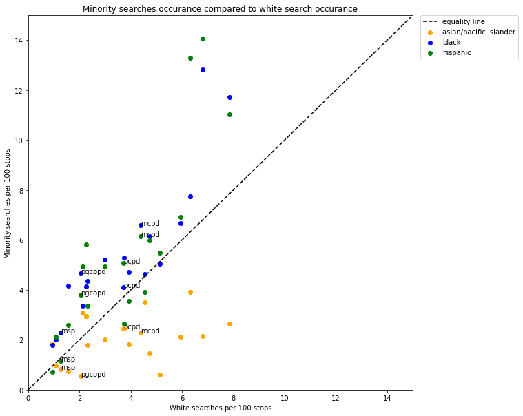

```python
fig, ax = plt.subplots(figsize=(10,10))
ax.set_title('Minority searches occurance compared to white search occurance')
ax.set_ylabel('Minority searches per 100 stops')
ax.set_xlabel('White searches per 100 stops')
ax.axline((1, 1), slope=1, linestyle = '--', color = 'black')
ax.set_xlim([0, 15])
ax.set_ylim([0, 15])
colors = {'black': 'blue', 'hispanic': 'green', 'asian/pacific islander': 'orange'}

# Dictionary for abbreviating labels
wanted = {'maryland state police': 'msp', 'prince george\'s county police department': 'pgcopd', 'baltimore county police department': 'bcpd', 'montgomery county police department': 'mcpd'}

search_df = pd.DataFrame()
reg_df = pd.DataFrame()

for department in equivalents:
    current = by_department_race[by_department_race['department_name'] == department]

    # Combining acronyms and spelled out department names
    if equivalents[department]:
        current = pd.concat([current,
                             by_department_race[by_department_race['department_name'] == equivalents[department]]], ignore_index = True)
    dups = current['department_name'].unique().size

    by_race = current.groupby(['subject_race'], as_index = False).agg({'arrest_made': 'sum', 'citation_issued': 'sum',
                                                            'warning_issued': 'sum', 'subject_age': 'sum', 'outcome': 'sum', 'subject_sex': 'sum',
                                                            'search_conducted': 'sum', 'contraband_found': 'sum'})

    # Averaging the ages and dropping unknowns/other
    by_race['subject_age'] = by_race['subject_age'] / dups
    by_race = by_race[by_race['subject_race'].str.contains('unknown|other')==False]
    by_race.reset_index(drop = True, inplace = True)

    # Add rows to searches df
    for index, race in by_race.iterrows():
        insert = {'department': department, 'subject_race': race['subject_race'], 'hits': race['contraband_found'], 'searches': race['search_conducted']}
        search_df = search_df.append(insert, ignore_index = True)

    # Scatter the minority searches over white searchs
    white_row = by_race.loc[by_race['subject_race'] == 'white']
    white_searches = white_row['search_conducted']/white_row['outcome'] * 100

    by_race = by_race[by_race['subject_race'].str.contains('white')==False]
    for index, race in by_race.iterrows():
        minority_searches = race['search_conducted']/race['outcome'] * 100
        ax.scatter(white_searches, minority_searches, color = colors.get(race['subject_race']))
        if department in wanted:
            ax.annotate(wanted[department], (white_searches, minority_searches))
        insert = {'race': race['subject_race'], 'white_searches': white_searches[3], 'minority_searches': minority_searches}
        reg_df = reg_df.append(insert, ignore_index = True)

ax.legend(labels=['equality line','asian/pacific islander','black','hispanic'], bbox_to_anchor=(1.02, 1), loc='upper left', borderaxespad=0)
plt.show()
```

As we can see, most of the top 20 departments in Maryland seem to search black and hispanic-owned vehicles more often than Caucasian-owned. Suprisingly, by and large, Asian/Pacific Islander vehicles are searched at a lower rate.

It is important to note that this does not prove discrimination. For example, if minorities happen to carry contraband at higher rates (or lower in the case of the Asian/Pacific Islander community) than these search rates can be attributed to appropriate police work. Another step we can take is to look at the number of searches that turned up contraband vs the total number of searches conducted. This method called an outcome test, as well as another method, the threshold test are described by the Standard Open Policing Project [here](https://openpolicing.stanford.edu/findings/). However, I do not do so in this tutorial as the Maryland dataset has very little positive searches, making it difficult to draw any conclusions.

## Predicting number of minority searches per 100 stops

Using the above data, we can now attempt to predict the number of minority stops given the number of white stops. We will use a linear regression on this plot to see how these points compare to the dashed equality line.

```
Coefficients: [[0.97992247]]
```

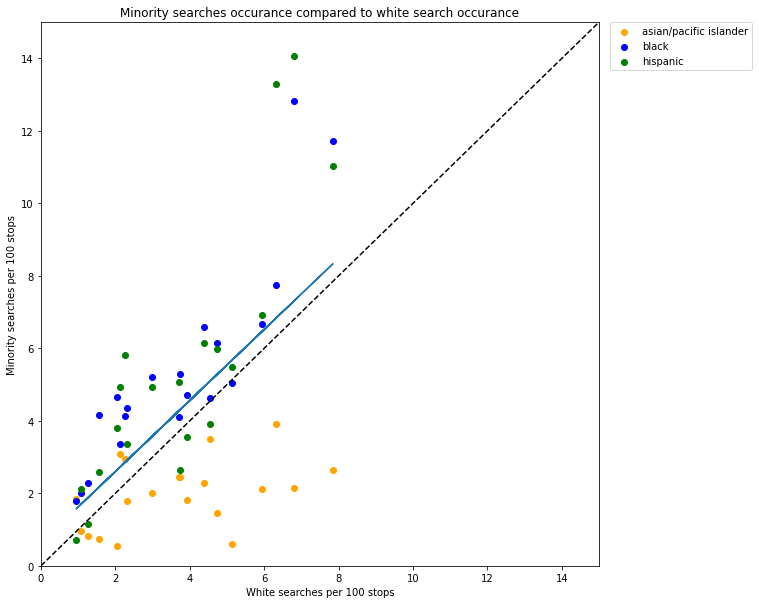

```python
model = LinearRegression()
X = [[x] for x in reg_df['white_searches'].values]
y = [[y] for y in reg_df['minority_searches'].values]
model.fit(X, y)

print("Coefficients: " + str(model.coef_))

fig, ax = plt.subplots(figsize=(10,10))
for index, row in reg_df.iterrows():
    ax.scatter(row['white_searches'], row['minority_searches'], color = colors.get(row['race']))
X = reg_df['white_searches'].values
X = X.reshape(-1,1)
ax.plot(reg_df['white_searches'], model.predict(X))
ax.axline((1, 1), slope=1, linestyle = '--', color = 'black')
ax.set_xlim([0, 15])
ax.set_ylim([0, 15])
ax.set_title('Minority searches occurance compared to white search occurance')
ax.set_ylabel('Minority searches per 100 stops')
ax.set_xlabel('White searches per 100 stops')
ax.legend(labels=['asian/pacific islander','black','hispanic'], bbox_to_anchor=(1.02, 1), loc='upper left', borderaxespad=0)

plt.show()
```

As we can see from the linear regression being above the equality line, minority drivers are searched more often than white drivers. However, it is clear that a majority of the points above the regression line are black and hispanic, while the majority of points below the line are asian/pacific islander. Therefore, we can hypothesize that there is an interaction between race and likelihood to be searched during a traffic stop.

Let's visualize this with a box plot of the residuals separated by race.

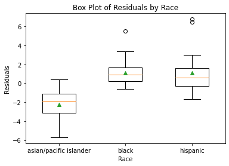

```python
reg_df['lin_res'] = 0
res_per_race = list()

# Calculating residuals for each row
for index, row in reg_df.iterrows():
    reg_df.at[index, 'lin_res'] = row['minority_searches'] - (row['white_searches'] * model.coef_[0][0] + model.intercept_[0])

for key in reg_df.drop_duplicates("race").race:
    race_data = reg_df.loc[reg_df['race'] == key]
    res_per_race.append(list(race_data['lin_res']))

fig, ax = plt.subplots()
ax.boxplot(res_per_race,widths=.5,showmeans=True)
plt.xticks([1, 2, 3], ['asian/pacific islander', 'black', 'hispanic'])
ax.set_xlabel("Race")
ax.set_ylabel("Residuals")
ax.set_title("Box Plot of Residuals by Race")

plt.show()
```

There seems to be a substantial difference between the asian/pacific islander residuals and both the black and hispanic residuals. Using one-hot enocding we can convert the categorical variable of race into variables that a linear regression can be performed on.

```
Coefficients: [0.33254582 1.27212198 1.33509959]
```

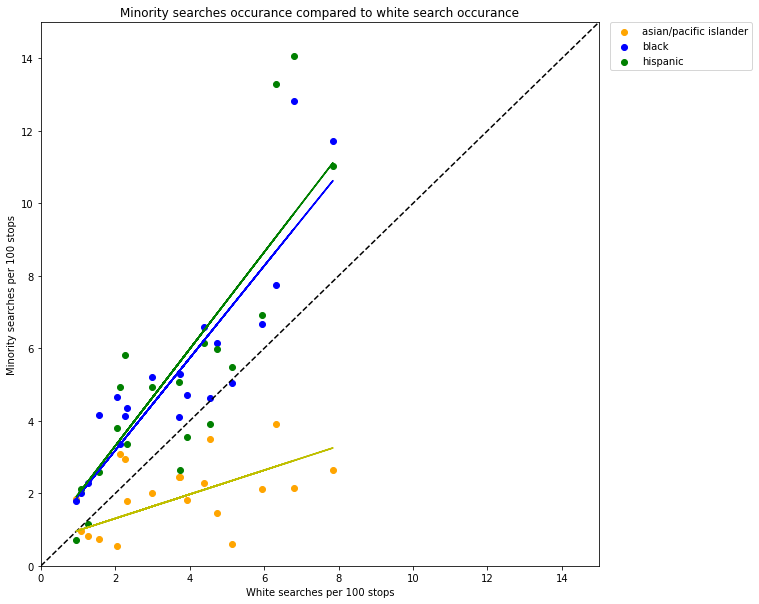

```python
y = reg_df.iloc[:, 2].values

# Onehot encoding for race
onehot = pd.get_dummies(reg_df['race'])
reg_df = pd.concat([reg_df, onehot], axis=1)
X2 = pd.DataFrame()

X2["asian/pacific islander"] = reg_df["white_searches"] * onehot["asian/pacific islander"]
X2["black"] = reg_df["white_searches"] * onehot["black"]
X2["hispanic"] = reg_df["white_searches"] * onehot["hispanic"]

regr2 = LinearRegression()
X2 = X2.values
regr2.fit(X2, y)
y_pred = regr2.predict(X2)

print("Coefficients: " + str(regr2.coef_))

fig, ax = plt.subplots(figsize=(10,10))
for index, row in reg_df.iterrows():
    ax.scatter(row['white_searches'], row['minority_searches'], color = colors.get(row['race']))
ax.axline((1, 1), slope=1, linestyle = '--', color = 'black')
ax.plot(reg_df['white_searches'], reg_df['white_searches'] * regr2.coef_[0] + regr2.intercept_, '-y')
ax.plot(reg_df['white_searches'], reg_df['white_searches'] * regr2.coef_[1] + regr2.intercept_, '-b')
ax.plot(reg_df['white_searches'], reg_df['white_searches'] * regr2.coef_[2] + regr2.intercept_, '-g')
ax.set_xlim([0, 15])
ax.set_ylim([0, 15])
ax.legend(labels=['asian/pacific islander','black','hispanic'], bbox_to_anchor=(1.02, 1), loc='upper left', borderaxespad=0)
ax.set_title('Minority searches occurance compared to white search occurance')
ax.set_ylabel('Minority searches per 100 stops')
ax.set_xlabel('White searches per 100 stops')
plt.show()
```

Based on the coefficicents listed above, we have evidence that in the top 20 departments in Maryland between 2013-2014, Asian/Pacific Islanders were searched at a rate of .33 searches per 1 search of the Caucasian community. Blacks and Hispanics were searched at a rate of 1.27 and 1.34 searches per 1 search of the Caucasian community.

Below we take a look at the effect of adding an interaction term on our residuals.

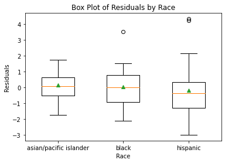

```python
reg_df['lin_res2'] = 0
res_per_race = list()

# Calculating residuals for each row
for index, row in reg_df.iterrows():
    if row['race'] == 'asian/pacific islander':
        interact = 0
    elif row['race'] == 'black':
        interact = 1
    else:
        interact = 2
    reg_df.at[index, 'lin_res2'] = row['minority_searches'] - (row['white_searches'] * regr2.coef_[interact] + regr2.intercept_)

for key in reg_df.drop_duplicates("race").race:
    race_data = reg_df.loc[reg_df['race'] == key]
    res_per_race.append(list(race_data['lin_res2']))

fig, ax = plt.subplots()
ax.boxplot(res_per_race,widths=.5,showmeans=True)
plt.xticks([1, 2, 3], ['asian/pacific islander', 'black', 'hispanic'])
ax.set_xlabel("Race")
ax.set_ylabel("Residuals")
ax.set_title("Box Plot of Residuals by Race")

plt.show()
```

As expected, we have corrected the overestimating of the number of searches of Asian/Pacific Islander vehicles as well as generally reduced the residuals over all minorities.

```python
X3 = sm.add_constant(X2)
est = sm.OLS(y, X3)
est2 = est.fit()
print(est2.summary())
```

```
                            OLS Regression Results
==============================================================================
Dep. Variable:                      y   R-squared:                       0.778
Model:                            OLS   Adj. R-squared:                  0.766
Method:                 Least Squares   F-statistic:                     65.43
Date:                Sat, 07 May 2022   Prob (F-statistic):           2.67e-18
Time:                        21:06:47   Log-Likelihood:                -107.56
No. Observations:                  60   AIC:                             223.1
Df Residuals:                      56   BIC:                             231.5
Df Model:                           3
Covariance Type:            nonrobust
==============================================================================
                 coef    std err          t      P>|t|      [0.025      0.975]
------------------------------------------------------------------------------
const          0.6422      0.412      1.560      0.124      -0.182       1.467
x1             0.3325      0.118      2.808      0.007       0.095       0.570
x2             1.2721      0.118     10.743      0.000       1.035       1.509
x3             1.3351      0.118     11.274      0.000       1.098       1.572
==============================================================================
Omnibus:                        8.978   Durbin-Watson:                   1.574
Prob(Omnibus):                  0.011   Jarque-Bera (JB):                9.031
Skew:                           0.705   Prob(JB):                       0.0109
Kurtosis:                       4.274   Cond. No.                         5.82
==============================================================================

Notes:
[1] Standard Errors assume that the covariance matrix of the errors is correctly specified.
```

# Conclusion

All results and figures discussed in this tutorial should be taken with a grain of salt as the Maryland Dataset is far from comprehensive. However, despite the Open Policing Project deciding to exclude this dataset from their analysis, I believe that we are still able to derive insights into the affect of race on the outcome of a traffic stop in Maryland. While the results of this tutorial clearly points towards showing that African Americans and Hispanics experiencing some level of discrimination during traffic stops, there are many arguments against this view. For example, one can reason that the difference in number of searches can be attributed to appropriate police work if these races are known to carry contraband at higher rates. As stated by the Open Policing Project: "Disentangling discrimination from effective policing is challenging and requires more subtle statistical analysis." Unfortunately, due to the lacking quality of Maryland traffic stop data, I was unable to delve deeper into the effects of discrimination.

The tools of data science are powerful in holding us accountable for our actions. However, it can only be as effective as the extent of the data available. A major limiting factor of the dataset used in this tutorial was the lack of standardization and gaps in the records. One possible route for analysis that I decided against pursuing was using a geocoder to derive latitude and longitude data from the locations recorded in the data. I felt that this conversion would introduce too much inaccuracy to provide meaningful insights.

## Works Cited

E. Pierson, C. Simoiu, J. Overgoor, S. Corbett-Davies, D. Jenson, A. Shoemaker, V. Ramachandran, P. Barghouty, C. Phillips, R. Shroff, and S. Goel. “A large-scale analysis of racial disparities in police stops across the United States”. Nature Human Behaviour, Vol. 4, 2020.